# Homework 3 Visual Solutions

This assignment is intended to give you experience programming and analyzing random variables in R and using those random variables to conduct statistical inference. You won’t need to bring in your own datasets—everything you need comes from R packages. Homework datasets and solutions are included in the `stat1080r` course package, so make sure you have the latest version installed before you begin.

You’ll complete this file by finishing the code and filling in the answer prompts. Replace each `#...#` with the code needed to answer the question. Sometimes I’ll give you a code “shell” (marked with `##`) that you’ll need to uncomment and complete.

When you’re done, submit your `.qmd` file in Canvas. Be sure it successfully renders to HTML with all your answers showing. Also remember to run `lintr` on your assignment so that you don’t lose points for style.

There are 3 problems in this assignment (each with several parts), worth a total of 80 points. Don’t forget to check the style guidelines at the end before submitting. Note that you must use the “modern” pipe command `|>` in your code. Please avoid the use of the old `%>%` in your code which will result in a loss of points.

# Problem 1 (15 points)

A small, but consequential, mistake has crept into the cereal dataset that we have used in previous homework assignments in this course. Our goal in this problem is to identify the mistake in the dataset using summary statistics and visuals. For this, we will compare summary statistics from the `cereal` and `cereal_infected` datasets.

```
   Shelf                      Name Manufacturer Type Calories Protein Fat
1    Top                 100%_Bran            N    C       70       4   1
2    Top         100%_Natural_Bran            Q    C      120       3   5
3    Top                  All-Bran            K    C       70       4   1
4    Top All-Bran_with_Extra_Fiber            K    C       50       4   0
5    Top            Almond_Delight            R    C      110       2   2
6 Bottom   Apple_Cinnamon_Cheerios            G    C      110       2   2
  Sodium Fiber Carbohydrates Sugars Potassium Vitamins Weight Cups
1    130  10.0           5.0      6       280       25      1 0.33
2     15   2.0           8.0      8       135        0      1 1.00
3    260   9.0           7.0      5       320       25      1 0.33
4    140  14.0           8.0      0       330       25      1 0.50
5    200   1.0          14.0      8        NA       25      1 0.75
6    180   1.5          10.5     10        70       25      1 0.75
```

```
Rows: 77
Columns: 15
$ Shelf         <chr> "Top", "Top", "Top", "Top", "Top", "Bottom", "Middle", "…
$ Name          <chr> "100%_Bran", "100%_Natural_Bran", "All-Bran", "All-Bran_…
$ Manufacturer  <chr> "N", "Q", "K", "K", "R", "G", "K", "G", "R", "P", "Q", "…
$ Type          <chr> "C", "C", "C", "C", "C", "C", "C", "C", "C", "C", "C", "…
$ Calories      <int> 70, 120, 70, 50, 110, 110, 110, 130, 90, 90, 120, 110, 1…
$ Protein       <int> 4, 3, 4, 4, 2, 2, 2, 3, 2, 3, 1, 6, 1, 3, 1, 2, 2, 1, 1,…
$ Fat           <int> 1, 5, 1, 0, 2, 2, 0, 2, 1, 0, 2, 2, 3, 2, 1, 0, 0, 0, 1,…
$ Sodium        <int> 130, 15, 260, 140, 200, 180, 125, 210, 200, 210, 220, 29…
$ Fiber         <dbl> 10.0, 2.0, 9.0, 14.0, 1.0, 1.5, 1.0, 2.0, 4.0, 5.0, 0.0,…
$ Carbohydrates <dbl> 5.0, 8.0, 7.0, 8.0, 14.0, 10.5, 11.0, 18.0, 15.0, 13.0, …
$ Sugars        <dbl> 6, 8, 5, 0, 8, 10, 14, 8, 6, 5, 12, 1, 9, 7, 13, 3, 2, 1…
$ Potassium     <int> 280, 135, 320, 330, NA, 70, 30, 100, 125, 190, 35, 105, …
$ Vitamins      <int> 25, 0, 25, 25, 25, 25, 25, 25, 25, 25, 25, 25, 25, 25, 2…
$ Weight        <dbl> 1.00, 1.00, 1.00, 1.00, 1.00, 1.00, 1.00, 1.33, 1.00, 1.…
$ Cups          <dbl> 0.33, 1.00, 0.33, 0.50, 0.75, 0.75, 1.00, 0.75, 0.67, 0.…
```

## Part a (3 points)

Create two tables that show the following summary statistics for each dataset by shelf. Be sure to have your summary statistics ignore any missing observations in the dataset in order to avoid returning `NA` in the summary.

- `mean_sugars`
- `median_sugars`
- `sd_sugars`
- `mad_sugars` (median absolute deviation, see `mad()` function)

## Part b (3 points)

Based on the observed differences in the `cereal_diff` table, please describe the nature of the “infection” and identify which shelf the issue is occurring on.

## Part c (3 points)

In order to identify the outlier, we intend to use Tukey’s definition of a “far out” outlier, which, given a vector of observations $x$, is a value $v$ where
$$v < q_{25} - 3*IQR(x) \text{ OR } v > q_{75} + 3*IQR(x).$$
with $q_x$ representing the “xth” percentile of the vector $x$ and $IQR(x)$ representing the interquartile range.

Based on this definition, create a vector of length two called `bounds` that represents the threshold for identifying outlier observations of sugars. While we know that the issue occurs on the middle shelf, create your bounds by using the vector of ALL sugar measurements, regardless of shelf. Note that all your calculations for the bounds should be made using sugar information from `cereal_infected` dataset.

## Part d (3 points)

Observe that there is at least one obvious way in which we could “tighten” the `bounds` vector using context, rather than the data. Thinking about the physical limitations of sugar content, what would be an acceptable change to the vector of bounds for identifying outliers that would reduce its length?

## Part e (3 points)

Use the `bounds` vector and the `filter()` tidyverse function to create a dataset with all rows exceeding the outlier bounds. Use the `select()` function to make it so your dataset only contains the cereal name, shelf, sugar content, and the serving size in cups.

# Problem 2 - Random Variables (26 points)

Suppose that Kellogg cereal is conducting an especially “sweet” promotion for Frosted Flakes: in their next shipment of 50,000 boxes of cereal to Logan, they plan to place $40 vouchers to Buffalo wild wings in 2,500 of them.

You love Buffalo wild wings but hate Frosted Flakes. Thus, buying a cereal box for $3.50 with no voucher would be considered a total waste, while buying a cereal box with a voucher would be considered a net gain of $36.50.

## Part a (2 points)

Using R, write code for a random variable `k` that represents your possible payouts for the purchase of a single box of cereal. Assume that the number of cereal boxes you might purchase will be so small, relative to the total number of possible boxes, it is virtually equivalent to sampling the cereal boxes with replacement.

## Part c (3 points)

Now write a function that computes the net winnings/loss (i.e. sum) from the purchase of `n` boxes of cereal. Use this function in a Monte Carlo simulation of 10,000 replications of randomly purchasing 100 boxes of cereal and taking the net winnings/loss. Your function should take a single variable `n` that represents the size of the sample from which you calculate a sum.

## Part d (3 points)

What is the probability of getting a net gain from 100 boxes of cereal based on the Monte Carlo simulation? What is the probability of losing more than $300 based on the simulation? The code for this answer should make use of the `sim_k` vector you created in the previous problem part.

## Part e (5 points)

We would like to think that a sample size of 100 is large enough to invoke the central limit theorem. Create a qqplot of the simulated net gains/losses to check if the assumption is reasonably justified. Your plot should exactly match the one provided in the `hw3_sol`. Note that your plot should make use of the `sim_k` vector from earlier. You should also make use of the `scale()` function to map the `sim_k` values from their original units to the number of standard deviations away from the mean.

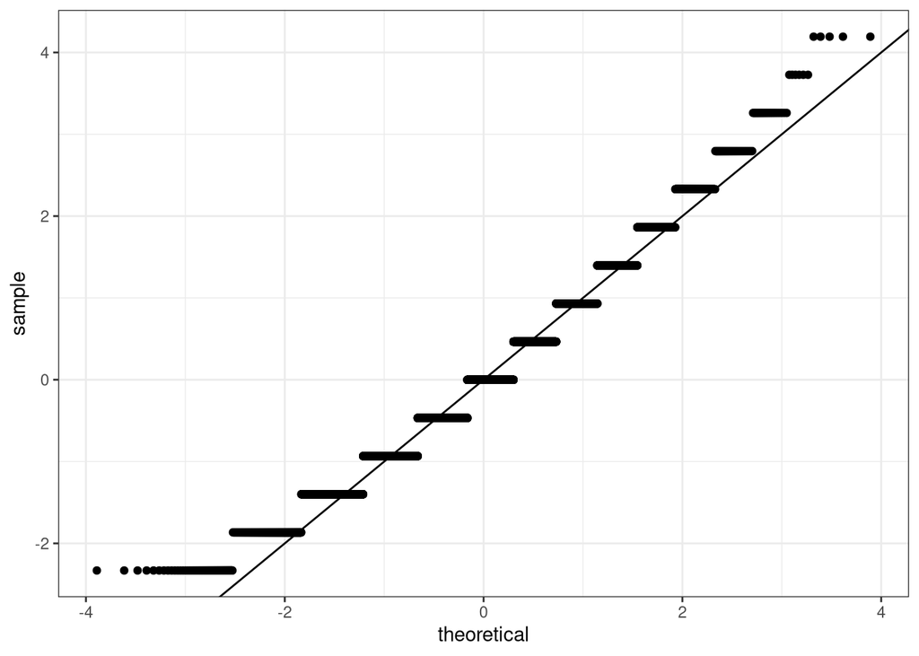

qqplot of Monte Carlo simulations of sum of winnings/losses from purchasing 100 boxes of cereal.

After making the visual, comment, with appropriate justification, on whether or not you feel that the net winnings/losses from the purchase of 100 boxes of cereal appears to follow a normal distribution.

## Part f (5 points)

Regardless of your answer to Part (d), assume that the sample size is large enough to use the Central Limit Theorem. Under the assumption of normality, what is the estimated probability of having a net positive gain when purchasing 100 boxes of cereal looking for vouchers? What is the probability of having a big loss (losing 300 dollars or more)? Save your answers as the variable `theory_gain` and `theory_big_loss` respectively. Note that you might want to create some intermediate variables (like the expected value and standard error) to help answer this question.

## Part g (5 points)

Repeat part (e), but now assume that you will buy 1000 boxes of cereal instead of 100. Report the change in probability for a net gain and a big loss (losing more than $300).

Write 1-3 sentences to explain why the probability of both events changed the way that it did.

# Problem 3 - Statistical Inference (29 points)

This problem is adapted from a real clinical trial (see https://clinicaltrials.gov/ct2/show/study/NCT04452435?recrs=e&cond=Covid19&draw=2) related to an oral medication used to treat patients hospitalized with COVID-19. One hope of the drug is that it will reduce the likelihood that the patient requires supplementary Oxygen in order to survive. Suppose it is known that 45% of patients hospitalized with COVID-19 require supplementary Oxygen (normally, this percentage also needs to be estimated with a Placebo group in a clinical trial, but we will, for now, suppose it is simply known). A random sample of 51 patients hospitalized with COVID-19 are given the experimental drug for a period of seven. **Of the 51 patients who took the drug, only 14 of them required supplemental oxygen.** We now seek to determine if taking the drug results in a significant reduction in the likelihood that a patient will require supplementary oxygen.

## Part a (2 points)

Write code that represents random variable `oxy` that represents the likelihood that a patient hospitalized with COVID-19 will require supplemental oxygen. Assume, for now, that the patient does not have access to the experimental drug.

## Part c (2 points)

Plot a histogram of the replicates. Use a bin width of 1/51, as that will fit the data best.

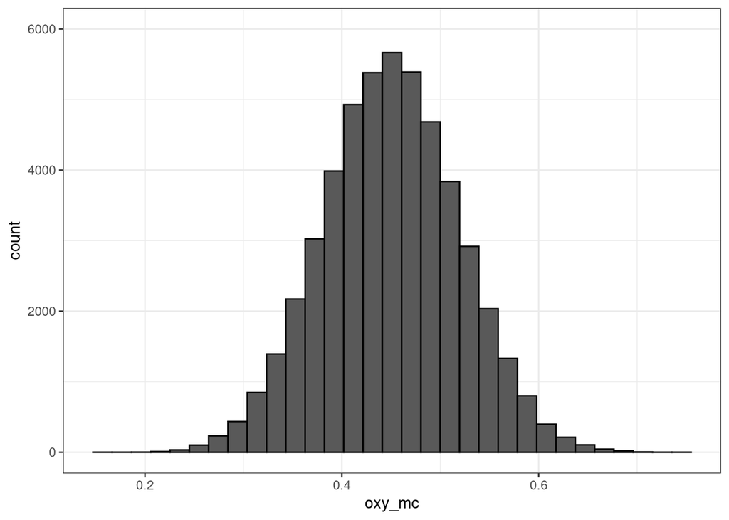

Histogram of Monte Carlo simulations of the sample proportion of people requiring supplemental oxygen in a sample of 51 patients.

## Part f (3 points)

In order to conduct statistical inference, we need a null hypothesis. The question we want to answer is whether or not the experimental drug changes the likelihood that a patient will require supplemental oxygen. Please write a null hypothesis appropriate to answer such a question.

## Part g (3 points)

Using your sample of 51 patients, create a 90% confidence interval for the true proportion of patients hospitalized with COVID-19, but take the experimental drug, that require supplemental oxygen. Note that you will need to use the `qnorm` function to determine the necessary multiplier for a 90% confidence interval (HINT: it is not 1.96!).

## Part h (2 points)

Comment on what your 90% confidence interval implies about your null hypothesis.

## Part i (4 points)

Using the null hypothesis, obtain a p-value for the sample proportion of patients hospitalized with COVID-19 who took the drug, yet still required supplemental oxygen. Based on this p-value, what can you say about the effectiveness of the drug in reducing the need for supplemental oxygen?

## Part j (5 points)

Now suppose that 2,365 out of a sample of 5,500 patients (i.e. 43%) who take the drug require supplemental oxygen. Redo Part (g) with this new sample size and sample proportion. What is the p-value? What does this say about the null hypothesis (i.e. $p = 0.45$)? Show the p-value with code and then comment below.

# Submission Style (10 points)

Each submission should have the following elements:

- You should submit the `.qmd` file (not the `HTML` rendering) with a file name in the style of `<last_name>_<first_name>_homework3.qmd`.
- Your `.qmd` file should run without errors when the grader attempts to render it to a html.
- Your code needs to run “clean” on any lintr checks. Please see the brief videos available on the “Style Guides” tabs of the course canvas page that introduce you to `lintr`, and `styler`. Note that you can ignore any flags with the tags: `trailing_whitespace_linter`, `trailing_blank_lines_linter`, and `commented_code_linter`.

# Submission Checklist

- Check your filename – is it of the form `lastname_firstname_homework02.qmd`?
- Check the author (specified around line 3 of this file) – is your name there?
- Render your file using the blue arrow at the top of the RStudio text editor window.
  - If your file does not render, address any errors in the code leading to failure.
- Preview your rendered file in a browser. Do all of your answers show up the way you expected them to?  
  If the answers do not show up the way you want them, check your markdown formatting against the cheat sheet in RStudio (Help -> Cheat Sheets -> Rmarkdown cheat sheets)
- Run the `lintr` style checks (Canvas -> Course homepage -> Style Guides link under USU picture)
  - Switch to source mode in RStudio
  - Addins -> Style active file
  - Addins -> Lint current file
  - Address any issues that the lint command raises
- Render your file again, to check that the `styler` and `lintr` addons didn’t mess up any formatting.
- Upload your **qmd** file (NOT the html file) to Canvas
- Double-check your submission - is the file you uploaded the one you want to be graded?